# R Notebook

# pre analyis setup

These are the packages that I will use. If you never used them then run install.packages(“NAME”) first.

## data loading

you can find the data file under cancor in the depository. The data was already cleanded so we can skip the cleaning process.

I was curious to see if the results would change based on standardization or not. That is why we have data.s for the scaled version of our data.

# correlation

We take a look at the corrolations between the X and Y variables. Y are variables that explain pulp characteristics whilt X are varibles representing paper characteristics.

to do so we fist use matcor.

```r
matcor(X,Y)
```

```
## $Xcor
##           x1        x2        x3        x4
## x1 1.0000000 0.9107697 0.9826030 0.9872925
## x2 0.9107697 1.0000000 0.9426271 0.8689088
## x3 0.9826030 0.9426271 1.0000000 0.9733630
## x4 0.9872925 0.8689088 0.9733630 1.0000000
##
## $Ycor
##            y1         y2         y3         y4
## y1  1.0000000  0.9197343 -0.7179439  0.7669334
## y2  0.9197343  1.0000000 -0.6853478  0.7717794
## y3 -0.7179439 -0.6853478  1.0000000 -0.7696908
## y4  0.7669334  0.7717794 -0.7696908  1.0000000
##
## $XYcor
##            x1         x2         x3         x4         y1         y2
## x1  1.0000000  0.9107697  0.9826030  0.9872925  0.6727682  0.7459194
## x2  0.9107697  1.0000000  0.9426271  0.8689088  0.5371154  0.6014069
## x3  0.9826030  0.9426271  1.0000000  0.9733630  0.7168111  0.7836993
## x4  0.9872925  0.8689088  0.9733630  1.0000000  0.7442507  0.8158694
## y1  0.6727682  0.5371154  0.7168111  0.7442507  1.0000000  0.9197343
## y2  0.7459194  0.6014069  0.7836993  0.8158694  0.9197343  1.0000000
## y3 -0.5419550 -0.5578692 -0.5818612 -0.5682841 -0.7179439 -0.6853478
## y4  0.8332547  0.8610245  0.8852613  0.8277318  0.7669334  0.7717794
##            y3         y4
## x1 -0.5419550  0.8332547
## x2 -0.5578692  0.8610245
## x3 -0.5818612  0.8852613
## x4 -0.5682841  0.8277318
## y1 -0.7179439  0.7669334
## y2 -0.6853478  0.7717794
## y3  1.0000000 -0.7696908
## y4 -0.7696908  1.0000000
```

While this is quite nice to see, it is not the best output to look at. lets try to do better.

## visuals of correlations

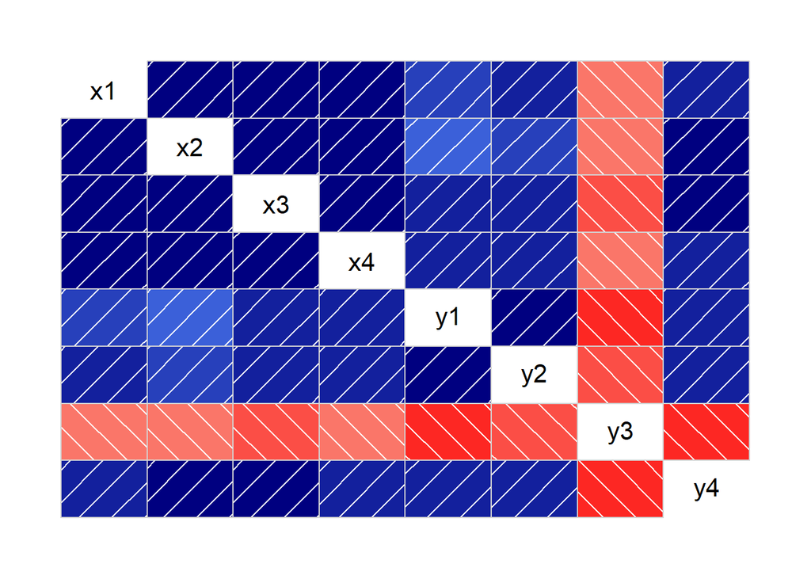

```r
corrgram::corrgram(data.s[,2:9])
```

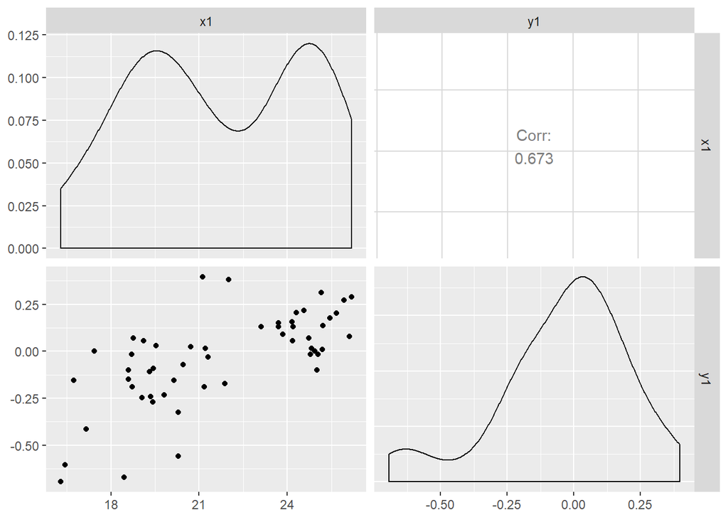

```r
ggpairs(datafr, columns = c(2,6))
```

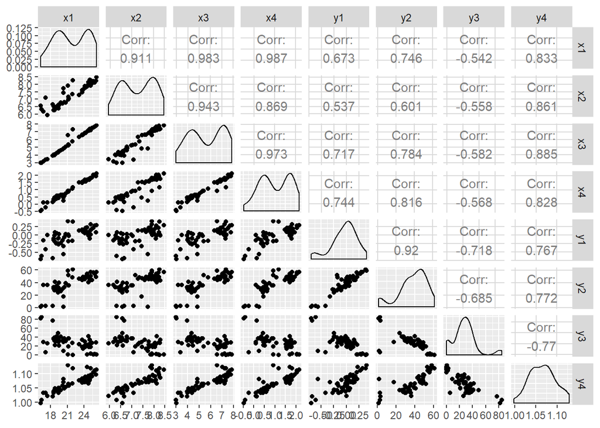

```r
ggpairs(datafr[,2:9])
```

y3 is fine fiber fraction. this seems to be negatively correlated to all other variables. The corgram clearly shows that with the red vetical and horizontal bars coming out of Y3.

next we use ggpairs to look at the nice visuals. There is quite a lot going on here. Lets explain what you see with a simple pair, take this; ggpairs(datafr, columns = c(2,6)). Where we look at the correlation for x1 and y1. In the top corner on the rhs we can see the numerical value of the correlation. On the lower lhs all ther dots are the data pairs. The densities are how the raw variables (or the standardized ones) X1 and Y1 are distributed.

You can also ask to see all of them in one giant plot However I will warn you this looks messy to some people.

## visuals per pair of variables

A simple solution to make the above plot less in your face is to split it up into the X and Y variables or to only keep the color plot we made with corrgram(data.s[,2:9]).

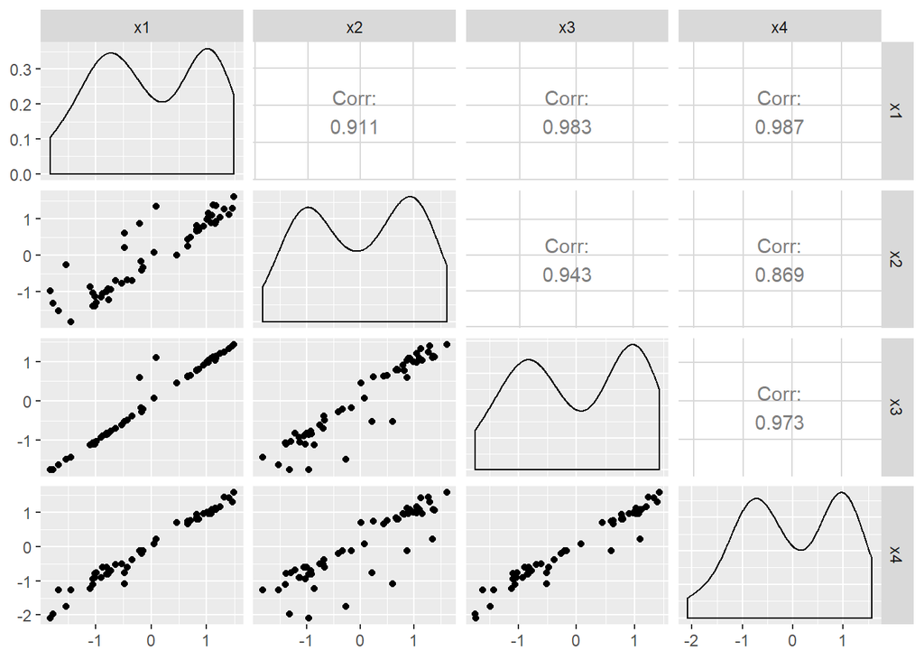

```r
x.dat <- as.data.frame(X)
y.dat <- as.data.frame(Y)

ggpairs(x.dat)
```

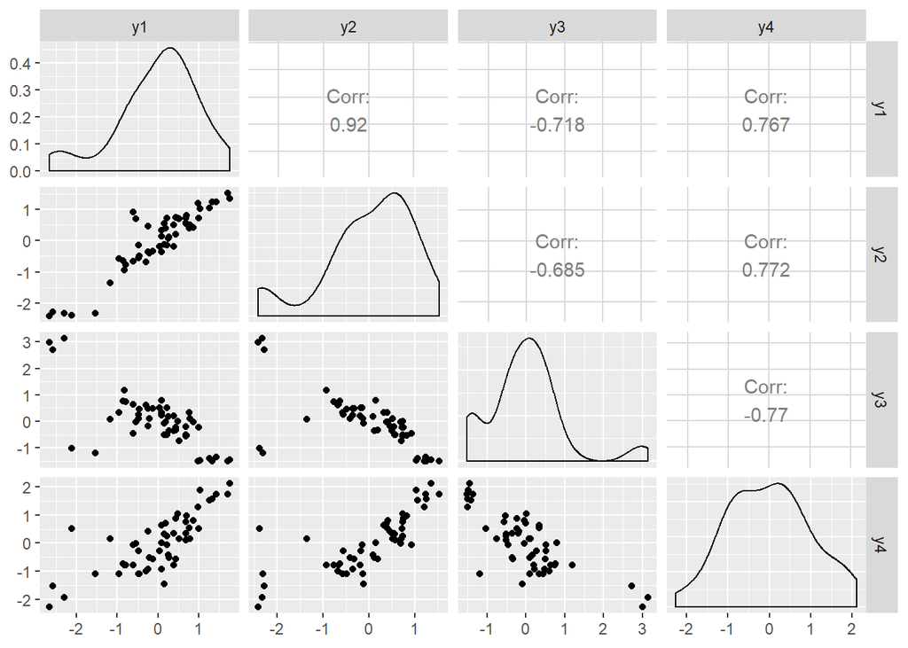

```r
ggpairs(y.dat)
```

# Cannon method

in order to do the cannonical correlation we use the CCA package.

```r
canon<-cc(X,Y)

canon.nots<-cc(Xr,Yr)


canoncor<-canon$cor
```

for now I won’t show the numerical output.

## cancor visuals.

Usually you want to know if the variables correlate in the same direction or if they move in opposite direction.

Dim1 is the frist cannoncial correlation of the X variables on the cannonical correlation of the Y variables. We can clearly see that all variables seem to move (strongly) negatively in both dimensions together while Y3 moves positively in both.

The second dimension the correlations are reduced and we see that now all Y variables except Y4 move in the opposite direction.

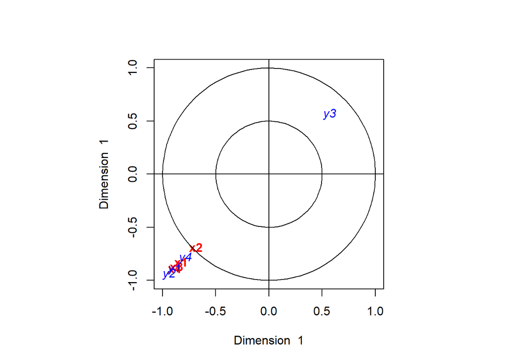

```r
plt.cc(canon.nots, type = "v", d1=1, d2=1,var.label = TRUE, ind.names = data.s[,1])
```

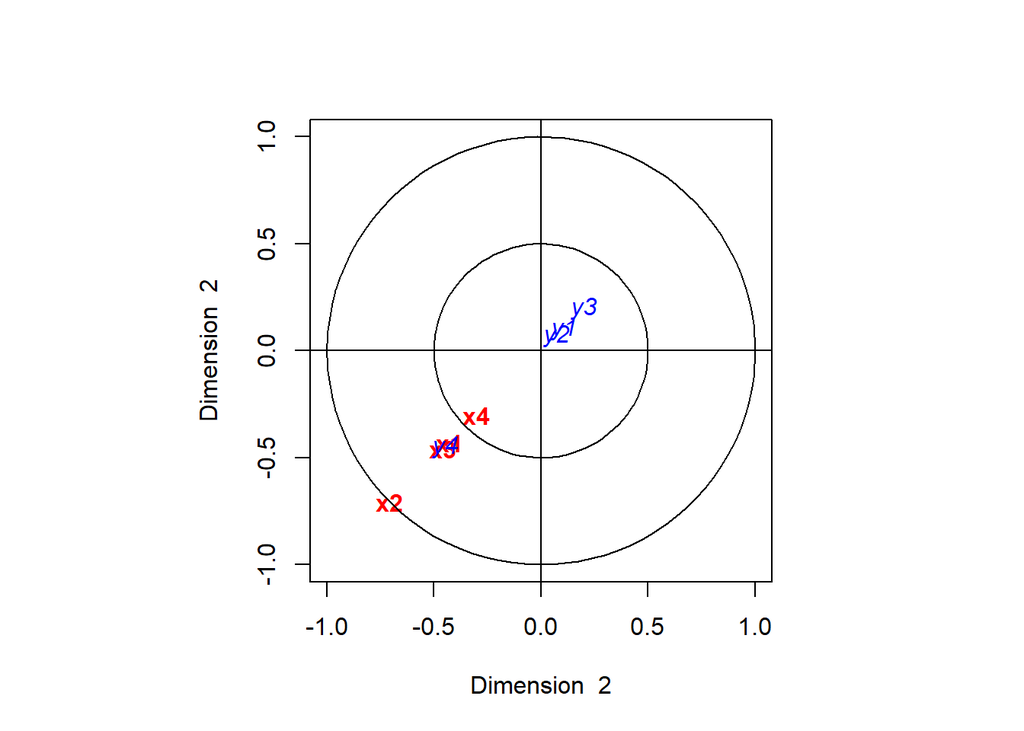

```r
plt.cc(canon.nots, type = "v", d1=2, d2=2,var.label = TRUE, ind.names = data.s[,1])
```

## cancor corrolation table

remeber in the method step I said we would skip the output? if you would visualize all the information you might be overwhelmed at first. The code below turns turns the numbers we want to see into a visually nice table form using Pander. (In html output there is not mush of a difference but there is when looking at the R-Console).

Important here is that you take the NAME$scores$corr.X.yscores from your cannoncial correlation. (*whatever name you gave the output).

```r
pander(canon$scores$corr.X.yscores)
```

| **x1** | -0.7954 | -0.3631 | -0.0004191 | 0.04992 |
| --- | --- | --- | --- | --- |
| **x2** | -0.661 | -0.5992 | -0.0421 | 0.01548 |
| **x3** | -0.8373 | -0.3881 | -0.004501 | 0.02576 |
| **x4** | -0.8531 | -0.2554 | -0.02386 | 0.04711 |

```r
pander(canon$scores$corr.Y.xscores)
```

| **y1** | -0.8904 | 0.106 | -0.05259 | -0.04397 |
| --- | --- | --- | --- | --- |
| **y2** | -0.9377 | 0.07217 | -0.06695 | 0.009223 |
| **y3** | 0.5686 | 0.2003 | 0.2352 | 0.03551 |
| **y4** | -0.7871 | -0.4483 | -0.05391 | -0.02192 |

# Am I done now?

We know how the two sets of variables are correlated. And for most people that will be enough.

For those who’s spiel is to “Deep Dive”, " Drill Deeper“, peel the onion or get more granular. There are a couple of things left for you to do to”add value“.

We did not check if the correlations are significant. Actually quite important.

Also we do not know how much of the correlation is explained by the different cannoncial dimensions.